# Extra results and examples of code functionality

Andrew Edwards

Last rendered on 15 August, 2024

This vignette follows on from the `results.Rmd` vignette, including:

Set up:

```r
library(hdiAnalysis)
library(dplyr)
```

## MCMC samples for multiple years – recruitments as in Figure 2A but plotting the full distributions

It is instructive to look at the full distributions of recruitment for each year.

For the multiple years of MCMC samples of hake recruitment, we calculate the results as in `results.Rmd` (see that for more details) and plot the full distributions with ETI and HDI for each year.

```r
res_all_years <- create_intervals(dplyr::select(hake_recruitment_mcmc,
                                                -"Virgin"))
```

The default plot (which uses `plot.intervals_density_list()`) is that shown in Figure 2A:

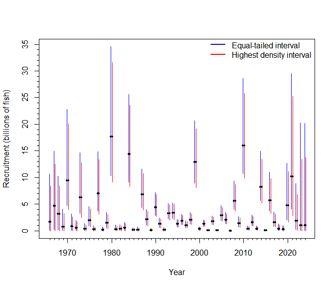

```r
plot(res_all_years,
     xlab = "Year",
     ylab = "Recruitment (billions of fish)")
```

To plot all density plots and ETIs for each year (equivalent to Figure 1A), the `type` argument is used (and we have changed the `fig.height` for the chunk, and specified `mfrow` as an argument, and fixed `xlim` so that it is the same for each plot). The year is automatically shown in each figure.

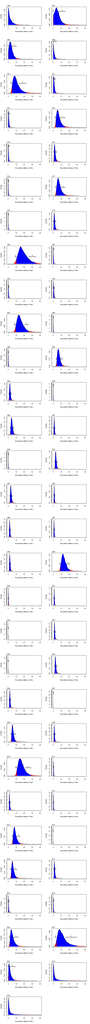

```r
plot(res_all_years,
     type = "eti",
     xlim = c(0, 40),
     xlab = "Recruitment (billions of fish)",
     mfrow = c(30, 2))  # 59 default



```

For the equvalent figures for HDIs, just change the `type` argument:

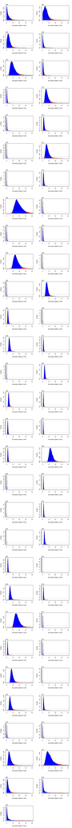

```r
plot(res_all_years,
     type = "hdi",
     xlim = c(0, 40),
     xlab = "Recruitment (billions of fish)",
     mfrow = c(30, 2))  # 59 default
```

## Detailed explanation of calculation of intervals ‘a’ and ‘b’ in Figure 1A

The calculation of intervals ‘a’ and ‘b’ in Fig. 1A is described in the Extended Methods, with explicit options given here to add helpful lines to further understanding:

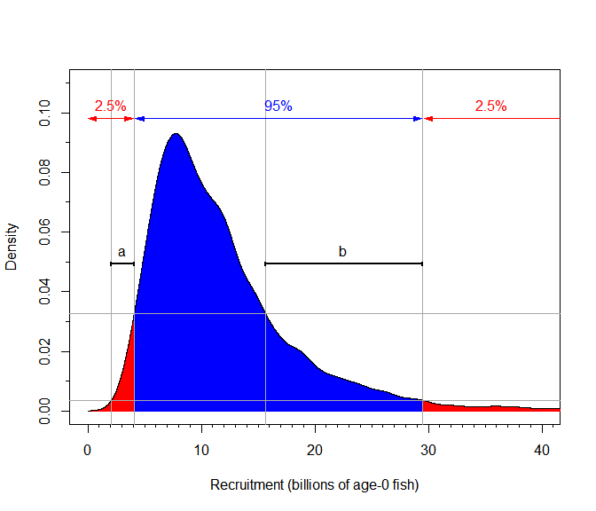

```r
res_vec <- create_intervals(rec_2021)

plot(res_vec,
     type = "eti",
     xlim = c(0, 40),
     ylim = c(0, 0.11),
     interval_arrows = TRUE,
     xlab = "Recruitment (billions of age-0 fish)",
     arrowhead_gap = 0.1,
     explanatory_lines_a_b = TRUE)
```

This shows the ETI in Fig. 1A but with extra lines. Two of the vertical grey lines show the recruitment values at the ends of the ETI (at the red/blue boundaries), denoting the right ends of ‘a’ and ‘b’. Horizontal grey lines show the densities at these two values; the intersection of these lines with the opposite limb of the distribution gives the other two vertical grey lines, defining the left ends of ‘a’ and ‘b’. Therefore, ‘a’ and ‘b’ both span the same range of densities on the y-axis, but ‘a’ is outside of the ETI while ‘b’ is inside of it.

Another undesirable feature of ETIs (for asymmetric distributions) is that there we can construct ranges `c` and `d` for which all values in `c` are more likely than those in `d`, yet `c` is outside the ETI and `d` is inside it:

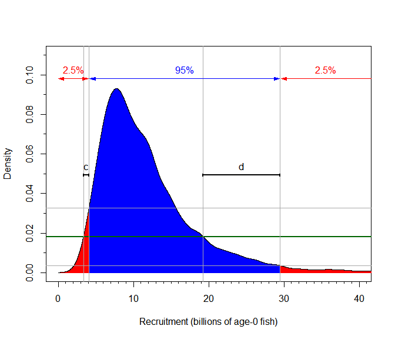

```r
plot(res_vec,
     type = "eti",
     xlim = c(0, 40),
     ylim = c(0, 0.11),
     interval_arrows = TRUE,
     xlab = "Recruitment (billions of age-0 fish)",
     arrowhead_gap = 0.1,
     explanatory_lines_a_b = FALSE,
     show_a_b = FALSE,
     explanatory_lines_extra = TRUE)
```

Here, the horizontal green line is set (as an example) at the mean of the densities at the ends of the ETI (horizontal grey lines are as in the previous figure). Its intersections with the density curve define the left ends of `c` and `d`, and all values within `c` are more likely than all those in `d`, but `c` is outside the ETI and `d` is inside it. The green line can be placed at any point between the two grey lines to create such ranges `c` and `d`. This includes at the density corresponding the HDI, as in Figure 12.2 of Kruschke (2015; Doing Bayesian Data Analysis: A Tutorial with R, JAGS, and Stan. 2nd Edition).

## Longer chain of 32,000 MCMC samples for hake recruitment in 2021

We also analysed an experimental longer chain of 32,000 MCMC samples (that took several days to run), and results are similar to the standard chain of 8,000 samples. Code is not run here (since the data object is large and so not included in the package) but results are presented below.

| Quantity | Value | Interval width |
| --- | --- | --- |
| Median | 10.20 | – |
| ETI | 4.05 – 29.53 | 25.49 |
| HDI | 2.89 – 25.23 | 22.34 |
| Range a | 2.27 – 4.05 | 1.78 |
| Range b | 16.02 – 29.53 | 13.52 |

The slight differences between the HDI for this chain and the one used in the main results are small compared to the difference to the ETI (for either chain). The ETIs change slightly between chains due to randomness between them, and the median even changes very slightly.

Also, the density values at the endpoints of the HDI are still not equal (they should be theoretically):

```r
> res_vec_long$interval$y_hdi_lower
[1] 0.01026998
> res_vec_long$interval$y_hdi_upper
[1] 0.007201427
```

These are similar to the results for the original chain, suggesting long MCMC chains will not result in the densities at the HDI endpoints being exactly equal. This is likely due to the true bumpy shape of the posterior and the approximations from the kernel density estimate required to estimate the densities.

Also, the integral over the HDI is estimated to be 94.7%, which is a slight improvement to the 94.5% for the original chain of 8,000 samples, but still not exactly 95%, such that the minor issue of the HDI not being exactly 95% is not resolved by using the longer chain.

## Computing the HDI on the kernel density estimate

Given the minor issue in Fig 1B that the densities at the endpoints of the HDI are not exactly equal, but they should be in theory, we also tried another approach to computing the HDI. This involved first calculating the kernel density estimate on the MCMC sample, and then using that to calculate the HDI. The HDInterval package includes the function to do this, which we incorporate into our `create_intervals()` function with the argument `density = TRUE`.

So repeating our Fig. 1B of 2021 hake recruitment, but using the density option, we obtain:

```r
res_2021_density <- create_intervals(rec_2021,
                                     density = TRUE)
res_2021_density$intervals %>% a()
```

```
#>    median eti_lower eti_upper hdi_lower hdi_upper width_eti width_hdi
#> 1 10.1873  4.085088  29.49938  2.529758  25.51794   25.4143  22.98818
#>   width_diff  a_lower  b_lower i_eti_lower y_eti_lower i_eti_upper y_eti_upper
#> 1   2.426113 2.081478 15.62305        3245  0.03280246       23427 0.003579759
#>   i_hdi_lower y_hdi_lower i_hdi_upper y_hdi_upper  hdi_height integral_full
#> 1        2010 0.007022643       20266 0.007013802 0.007013802             1
#>   integral_eti integral_hdi warning allow_hdi_zero
#> 1    0.9418215    0.9499948   FALSE          FALSE
```

with the main results being:

```r
summary_table(res_2021_density)
```

| Quantity | Value | Interval width |
| --- | --- | --- |
| Median | 10.19 | – |
| ETI | 4.09 – 29.50 | 25.41 |
| HDI | 2.53 – 25.52 | 22.99 |
| Range a | 2.08 – 4.09 | 2.00 |
| Range b | 15.62 – 29.50 | 13.88 |

The equivalent plot to our Fig. 1B for the calculated HDI is

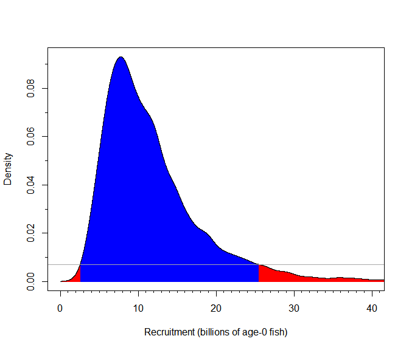

```r
plot(res_2021_density,
     xlim = c(0,40),
     xlab = "Recruitment (billions of age-0 fish)")
```

in which we can see that the heights of the two endpoints are equal.

Furthermore, the integral over the HDI is the theoretical 95%:

```r
res_2021_density$intervals$integral_hdi
```

```
#> [1] 0.9499948
```

One technical issue we resolved was that the default of 512 equally spaced points (`n`) at which to compute the kernal density estimate in the `density()` function, did not resolve the issue of unequal densities at the endpoints of the HDI. Setting the number of points to 512 here shows this:

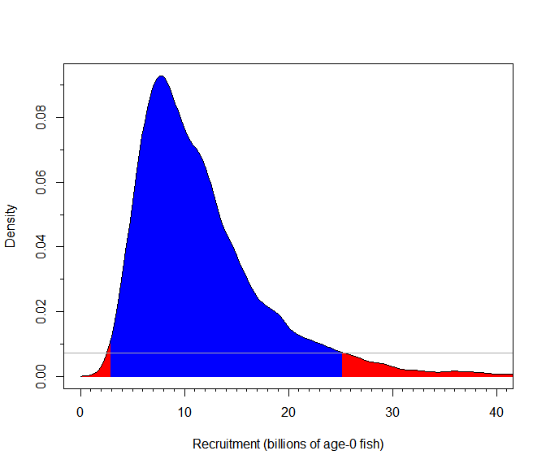

```r
res_2021_n_512 <- create_intervals(rec_2021,
                                   n = 512)
plot(res_2021_n_512,
     xlim = c(0, 40),
     xlab = "Recruitment (billions of age-0 fish)")
```

We found that increasing `n` to 100,000 resolved this (this does not increase the wiggliness of the kernel density estimate, just the number of points at which it is calculated), and hence is set as the default in our `create_intervals()` function.

So while the density approach (with `n=100,000`) did seem preferable, given the equal densities at the endpoints of the HDI, the following simple simulation experiment convinced us to stick with the moving-window approach. We present these results for interested users.

## Simulation experiment

We simulate 8,000 values from a lognormal distribution with mean on the log scale of 4 and standard deviation of 0.5, somewhat resembling our recruitment MCMC samples. We calculate the HDI using our default approach and with the density approach just described. We repeated this experiment 1,000 times, to compare the calculated HDI’s with the known true theoretical values (because we know the true underlying distribution, unlike for our MCMC samples).

The true theoretical values are calculated from the inverse cumulative distribution function for the lognormal distribution, using the function.

```r
mean_log <- 4
sd_log <- 0.5
n <- 8000

# True theoretical values:
hdi_true <- HDInterval::hdi(qlnorm,
                            credMass = 0.95,
                            meanlog = mean_log,
                            sdlog = sd_log)
hdi_true
```

```
#>     lower     upper
#>  14.28573 126.56281
#> attr(,"credMass")
#> [1] 0.95
```

```r
# Format into tibble output to match the $intervals output from `create_intervals()` to then
# easily append the results of the simulation:
ints_true <- tibble::tibble(median = qlnorm(0.5, mean_log, sd_log),
                            eti_lower = qlnorm(0.025, mean_log, sd_log),
                            eti_upper = qlnorm(0.975, mean_log, sd_log),
                            hdi_lower = hdi_true["lower"],
                            hdi_upper = hdi_true["upper"]) %>%
  dplyr::mutate(width_eti = eti_upper - eti_lower,
                width_hdi = hdi_upper - hdi_lower,
                width_diff = width_eti - width_hdi,
                a_lower = NA,
                b_lower = NA,
                i_eti_lower = NA,
                y_eti_lower = dlnorm(eti_lower,
                                     mean_log,
                                     sd_log),
                i_eti_upper = NA,
                y_eti_upper = dlnorm(eti_upper,
                                     mean_log,
                                     sd_log),
                i_hdi_lower = NA,
                y_hdi_lower = dlnorm(hdi_lower,
                                     mean_log,
                                     sd_log),
                i_hdi_upper = NA,
                y_hdi_upper = dlnorm(hdi_upper,
                                     mean_log,
                                     sd_log),
                hdi_height = NA,
                integral_full = NA,
                integral_eti = plnorm(eti_upper,
                                     mean_log,
                                     sd_log) -
                               plnorm(eti_lower,
                                      mean_log,
                                      sd_log),
                integral_hdi = plnorm(hdi_upper,
                                     mean_log,
                                     sd_log) -
                               plnorm(hdi_lower,
                                      mean_log,
                                      sd_log),
                warning = NA,
                allow_hdi_zero = NA)

ints_true %>% a()
```

```
#>     median eti_lower eti_upper hdi_lower hdi_upper width_eti width_hdi
#> 1 54.59815  20.49166  145.4718  14.28573  126.5628  124.9801  112.2771
#>   width_diff a_lower b_lower i_eti_lower y_eti_lower i_eti_upper  y_eti_upper
#> 1   12.70302      NA      NA          NA 0.005704279          NA 0.0008035246
#>   i_hdi_lower y_hdi_lower i_hdi_upper y_hdi_upper hdi_height integral_full
#> 1          NA 0.001533484          NA 0.001533484         NA            NA
#>   integral_eti integral_hdi warning allow_hdi_zero
#> 1         0.95         0.95      NA             NA
```

We can see that the densities at the two ends of the HDI are (exactly) equal, as expected:

```r
ints_true$y_hdi_lower
```

```
#>       lower
#> 0.001533484
```

```r
ints_true$y_hdi_upper
```

```
#>       upper
#> 0.001533484
```

Now to do 1,000 simulations, and compare the results to the theoretical values:

```r
num_sims <- 1000
simulations <- list()
# Set up a tibble to then add results for each simulation as a new row, with the
# first row being the theoretical results obtained above:

# Results when not using density option (our default):
ints_simulations_density_false <- cbind(type = "theoretical",
                                      ints_true)

# Results when using density option:
ints_simulations_density_true <- ints_simulations_density_false # same format

for(i in 1:num_sims){
  set.seed(i)
  this_sim <- rlnorm(n,
                     mean_log,
                     sd_log)

  # Not using density:
  this_int_density_false <- create_intervals(this_sim,
                                           density = FALSE)

  ints_simulations_density_false <- rbind(ints_simulations_density_false,
                                        cbind(type = i,
                                              this_int_density_false$intervals))

  # Using density:
  this_int_density_true <- create_intervals(this_sim,
                                           density = TRUE)

  ints_simulations_density_true <- rbind(ints_simulations_density_true,
                                        cbind(type = i,
                                              this_int_density_true$intervals))
}

ints_simulations_density_false <- tibble::as_tibble(ints_simulations_density_false)
ints_simulations_density_true <- tibble::as_tibble(ints_simulations_density_true)

ints_simulations_density_false
```

```
#> # A tibble: 1,001 × 25
#>    type       median eti_lower eti_upper hdi_lower hdi_upper width_eti width_hdi
#>    <chr>       <dbl>     <dbl>     <dbl>     <dbl>     <dbl>     <dbl>     <dbl>
#>  1 theoretic…   54.6      20.5      145.      14.3      127.      125.      112.
#>  2 1            54.1      19.8      149.      14.7      128.      129.      114.
#>  3 2            55.5      20.9      148.      13.9      127.      127.      113.
#>  4 3            54.4      20.3      147.      14.9      126.      126.      111.
#>  5 4            54.4      20.6      142.      15.3      125.      121.      110.
#>  6 5            54.4      20.1      150.      12.8      126.      130.      113.
#>  7 6            54.5      20.5      146.      15.6      129.      126.      113.
#>  8 7            54.8      20.7      151.      15.9      131.      130.      115.
#>  9 8            55.0      20.3      152.      13.0      127.      131.      114.
#> 10 9            55.0      20.7      144.      14.7      124.      123.      109.
#> # ℹ 991 more rows
#> # ℹ 17 more variables: width_diff <dbl>, a_lower <dbl>, b_lower <dbl>,
#> #   i_eti_lower <int>, y_eti_lower <dbl>, i_eti_upper <int>, y_eti_upper <dbl>,
#> #   i_hdi_lower <int>, y_hdi_lower <dbl>, i_hdi_upper <int>, y_hdi_upper <dbl>,
#> #   hdi_height <lgl>, integral_full <dbl>, integral_eti <dbl>,
#> #   integral_hdi <dbl>, warning <lgl>, allow_hdi_zero <lgl>
```

```r
ints_simulations_density_true
```

```
#> # A tibble: 1,001 × 25
#>    type       median eti_lower eti_upper hdi_lower hdi_upper width_eti width_hdi
#>    <chr>       <dbl>     <dbl>     <dbl>     <dbl>     <dbl>     <dbl>     <dbl>
#>  1 theoretic…   54.6      20.5      145.      14.3      127.      125.      112.
#>  2 1            54.1      19.8      149.      11.9      129.      129.      117.
#>  3 2            55.5      20.9      148.      12.8      128.      127.      115.
#>  4 3            54.4      20.3      147.      12.7      127.      126.      114.
#>  5 4            54.4      20.6      142.      12.9      126.      121.      113.
#>  6 5            54.4      20.1      150.      11.5      128.      130.      117.
#>  7 6            54.5      20.5      146.      12.8      128.      126.      116.
#>  8 7            54.8      20.7      151.      12.8      131.      130.      118.
#>  9 8            55.0      20.3      152.      11.8      129.      131.      117.
#> 10 9            55.0      20.7      144.      13.2      126.      123.      113.
#> # ℹ 991 more rows
#> # ℹ 17 more variables: width_diff <dbl>, a_lower <dbl>, b_lower <dbl>,
#> #   i_eti_lower <int>, y_eti_lower <dbl>, i_eti_upper <int>, y_eti_upper <dbl>,
#> #   i_hdi_lower <int>, y_hdi_lower <dbl>, i_hdi_upper <int>, y_hdi_upper <dbl>,
#> #   hdi_height <dbl>, integral_full <dbl>, integral_eti <dbl>,
#> #   integral_hdi <dbl>, warning <lgl>, allow_hdi_zero <lgl>
```

So we have 1,000 HDIs for each option (using `density` or not), so plot the intervals and compare with the known values. Show the HDIs, including the first one that represents the theoretical HDI which we illustrate with in red, and plot vertical red lines for its endpoints, to compare with the simulated HDIs:

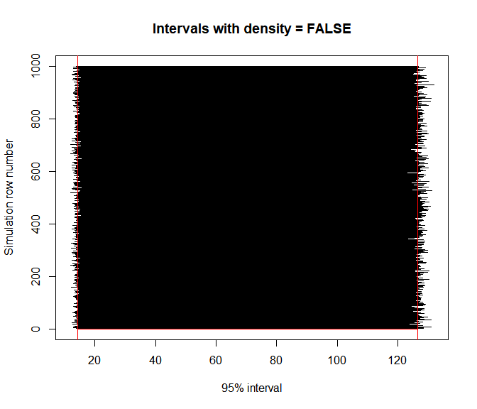

```r
# Set up plot
plot(range(c(ints_simulations_density_false$hdi_lower,
             ints_simulations_density_false$hdi_upper)),
     c(1, nrow(ints_simulations_density_false)),
     type = "n",
     xlab = "95% interval",
     ylab = "Simulation row number",
     main = "Intervals with density = FALSE")

lines(c(ints_simulations_density_false[1, "hdi_lower"],
        ints_simulations_density_false[1, "hdi_upper"]),
      c(1, 1),
      col = "red")
for(i in 1:num_sims){
  lines(c(ints_simulations_density_false[i+1, "hdi_lower"],
        ints_simulations_density_false[i+1, "hdi_upper"]),
      c(i+1, i+1),
      col = "black")
}
abline(v = c(ints_simulations_density_false[1, "hdi_lower"],
             ints_simulations_density_false[1, "hdi_upper"]),
       col = "red")
```

These look okay, but to more clearly compare we show histograms of lower and upper HDI values compared to true theoretical value (includes the theoretical value in the histogram):

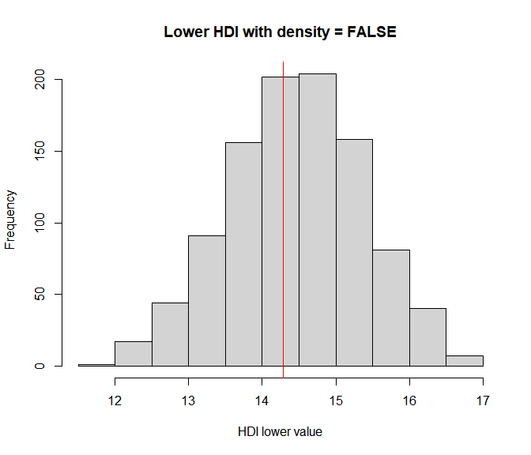

```r
hist(ints_simulations_density_false$hdi_lower,
     xlab = "HDI lower value",
     main = "Lower HDI with density = FALSE")
abline(v = ints_simulations_density_false[1, "hdi_lower"], col = "red")
```

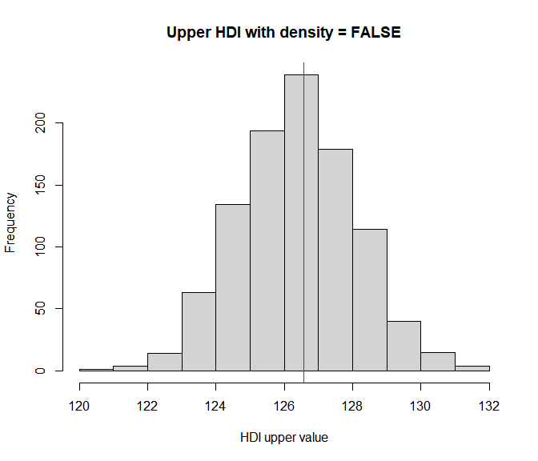

```r
hist(ints_simulations_density_false$hdi_upper,
     xlab = "HDI upper value",
     main = "Upper HDI with density = FALSE")
abline(v = ints_simulations_density_false[1, "hdi_upper"], col = "red")
```

The actual numbers of simulated lower endpoints of HDI above the true value is

```r
sum(ints_simulations_density_false$hdi_lower[-1] > ints_simulations_density_false$hdi_lower[1])
```

```
#> [1] 573
```

and the number of upper endpoints above the true value is

```r
sum(ints_simulations_density_false$hdi_upper[-1] > ints_simulations_density_false$hdi_upper[1])
```

```
#> [1] 454
```

So not exactly half (500), but okay.

Now to do the same plots for the results when using the density approach to calculating the HDIs:

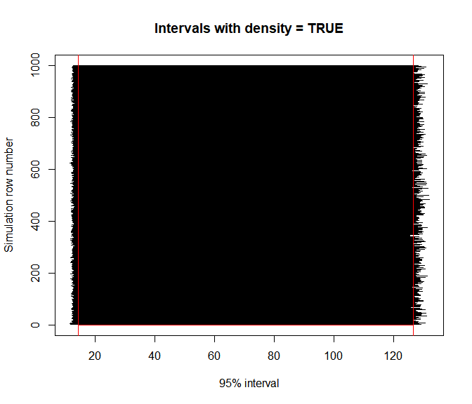

```r
# Set up plot
plot(range(c(ints_simulations_density_true$hdi_lower,
             ints_simulations_density_true$hdi_upper)),
     c(1, nrow(ints_simulations_density_true)),
     type = "n",
     xlab = "95% interval",
     ylab = "Simulation row number",
     main = "Intervals with density = TRUE")

lines(c(ints_simulations_density_true[1, "hdi_lower"],
        ints_simulations_density_true[1, "hdi_upper"]),
      c(1, 1),
      col = "red")
for(i in 1:num_sims){
  lines(c(ints_simulations_density_true[i+1, "hdi_lower"],
        ints_simulations_density_true[i+1, "hdi_upper"]),
      c(i+1, i+1),
      col = "black")
}
abline(v = c(ints_simulations_density_true[1, "hdi_lower"],
             ints_simulations_density_true[1, "hdi_upper"]),
       col = "red")
```

These do not look great at the low end, as we can see from the histogram (the one value on the right in the first panel is indeed the true theoretical value as it’s included in the tibble of lower HDI values):

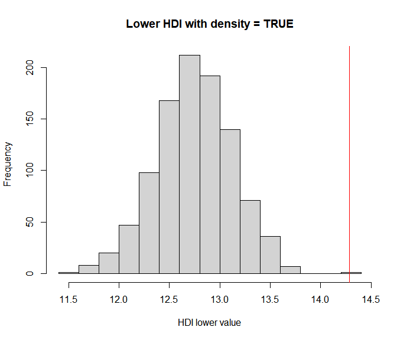

```r
hist(ints_simulations_density_true$hdi_lower,
     xlab = "HDI lower value",
     main = "Lower HDI with density = TRUE")
abline(v = ints_simulations_density_true[1, "hdi_lower"], col = "red")
```

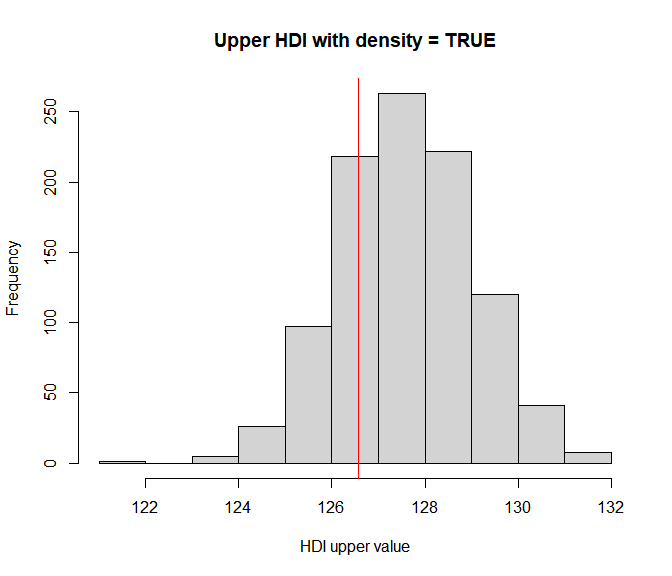

```r
hist(ints_simulations_density_true$hdi_upper,
     xlab = "HDI upper value",
     main = "Upper HDI with density = TRUE")
abline(v = ints_simulations_density_true[1, "hdi_upper"], col = "red")
```

The actual numbers of simulated lower endpoints of HDI above the true value is

```r
sum(ints_simulations_density_true$hdi_lower[-1] > ints_simulations_density_true$hdi_lower[1])
```

```
#> [1] 0
```

and the number of upper endpoints above the true value is

```r
sum(ints_simulations_density_true$hdi_upper[-1] > ints_simulations_density_true$hdi_upper[1])
```

```
#> [1] 764
```

So these values are quite a way off being the desired half (500). This convinced us to stick with the simpler no-density method.